# Tidy Genomics Answers

```r
library(tidyverse)
```

## Task 1: Data import and examination

### How many rows and columns are there?

```r
raw = read_tsv("data/Brauer2008_DataSet1.tds")
#raw = read_delim("data/Brauer2008_DataSet1.tds")
glimpse(raw)
```

```
## Observations: 5,537
## Variables: 40
## $ GID     <chr> "GENE1331X", "GENE4924X", "GENE4690X", "GENE1177X", "G...
## $ YORF    <chr> "A_06_P5820", "A_06_P5866", "A_06_P1834", "A_06_P4928"...
## $ NAME    <chr> "SFB2       || ER to Golgi transport || molecular func...
## $ GWEIGHT <int> 1, 1, 1, 1, 1, 1, 1, 1, 1, 1, 1, 1, 1, 1, 1, 1, 1, 1, ...
## $ G0.05   <dbl> -0.24, 0.28, -0.02, -0.33, 0.05, -0.69, -0.55, -0.75, ...
## $ G0.1    <dbl> -0.13, 0.13, -0.27, -0.41, 0.02, -0.03, -0.30, -0.12, ...
## $ G0.15   <dbl> -0.21, -0.40, -0.27, -0.24, 0.40, 0.23, -0.12, -0.07, ...
## $ G0.2    <dbl> -0.15, -0.48, -0.02, -0.03, 0.34, 0.20, -0.03, 0.02, 0...
## $ G0.25   <dbl> -0.05, -0.11, 0.24, -0.03, -0.13, 0.00, -0.16, -0.32, ...
## $ G0.3    <dbl> -0.05, 0.17, 0.25, 0.00, -0.14, -0.27, -0.11, -0.41, -...
## $ N0.05   <dbl> 0.20, 0.31, 0.23, 0.20, -0.35, 0.17, 0.04, 0.11, 0.30,...
## $ N0.1    <dbl> 0.24, 0.00, 0.06, -0.25, -0.09, -0.40, 0.00, -0.16, 0....
## $ N0.15   <dbl> -0.20, -0.63, -0.66, -0.49, -0.08, -0.54, -0.63, -0.26...
```

[output cut: 27 more lines]

### What do the rows and columns represent?

Rows are genes and columns are a mix of different variables including gene names and expression values

### On first glimpse do the column datatypes look correct?

Yes, it seems that `readr` had guessed correctly on what the values should be.

### What about column names?

The columns that have the gene expression values don’t look right. Something is up with that period in there.

### Is this data tidy? Why or why not?

It’s not. Each observation does not form a row and each variable does not form a column.

## Task 2: Data Tidying

### Which column contains multiple variables? Split it up so each column represents a single variable.

We need to tell `separate()` to split on the `||` character using the `sep` argument. However, the `|` character is actually a special character for something called regular expressions, which we don’t need to worry about right now. That’s why we need to use the double backslash, which “escapes” the `|` character and tells `separate()` to interpret it like a normal character. If we used `sep = "||"` this would give us the wrong result.

```r
head(raw)
```

```
## # A tibble: 6 x 40
##   GID    YORF  NAME   GWEI…   G0.05    G0.1  G0.15    G0.2   G0.25    G0.3
##   <chr>  <chr> <chr>  <int>   <dbl>   <dbl>  <dbl>   <dbl>   <dbl>   <dbl>
## 1 GENE1… A_06… SFB2 …     1 -0.240  -0.130  -0.210 -0.150  -0.0500 -0.0500
## 2 GENE4… A_06… || bi…     1  0.280   0.130  -0.400 -0.480  -0.110   0.170
## 3 GENE4… A_06… QRI7 …     1 -0.0200 -0.270  -0.270 -0.0200  0.240   0.250
## 4 GENE1… A_06… CFT2 …     1 -0.330  -0.410  -0.240 -0.0300 -0.0300  0
## 5 GENE5… A_06… SSO2 …     1  0.0500  0.0200  0.400  0.340  -0.130  -0.140
## 6 GENE2… A_06… PSP2 …     1 -0.690  -0.0300  0.230  0.200   0      -0.270
## # ... with 30 more variables: N0.05 <dbl>, N0.1 <dbl>, N0.15 <dbl>, N0.2
## #   <dbl>, N0.25 <dbl>, N0.3 <dbl>, P0.05 <dbl>, P0.1 <dbl>, P0.15 <dbl>,
## #   P0.2 <dbl>, P0.25 <dbl>, P0.3 <dbl>, S0.05 <dbl>, S0.1 <dbl>, S0.15
## #   <dbl>, S0.2 <dbl>, S0.25 <dbl>, S0.3 <dbl>, L0.05 <dbl>, L0.1 <dbl>,
## #   L0.15 <dbl>, L0.2 <dbl>, L0.25 <dbl>, L0.3 <dbl>, U0.05 <dbl>, U0.1
## #   <dbl>, U0.15 <dbl>, U0.2 <dbl>, U0.25 <dbl>, U0.3 <dbl>
```

```r
raw %>%
  separate(NAME, c("gene_name", "BP", "MP", "gene_id", "number"), sep = "\\|\\|")
```

```
## # A tibble: 5,537 x 44
##    GID   YORF  gene… BP    MP    gene… numb… GWEI…   G0.05    G0.1   G0.15
##  * <chr> <chr> <chr> <chr> <chr> <chr> <chr> <int>   <dbl>   <dbl>   <dbl>
##  1 GENE… A_06… "SFB… " ER… " mo… " YN… " 10…     1 -0.240  -0.130  -0.210
##  2 GENE… A_06… ""    " bi… " mo… " YN… " 10…     1  0.280   0.130  -0.400
##  3 GENE… A_06… "QRI… " pr… " me… " YD… " 10…     1 -0.0200 -0.270  -0.270
##  4 GENE… A_06… "CFT… " mR… " RN… " YL… " 10…     1 -0.330  -0.410  -0.240
##  5 GENE… A_06… "SSO… " ve… " t-… " YM… " 10…     1  0.0500  0.0200  0.400
##  6 GENE… A_06… "PSP… " bi… " mo… " YM… " 10…     1 -0.690  -0.0300  0.230
##  7 GENE… A_06… "RIB… " ri… " ps… " YO… " 10…     1 -0.550  -0.300  -0.120
##  8 GENE… A_06… "VMA… " va… " hy… " YP… " 10…     1 -0.750  -0.120  -0.0700
##  9 GENE… A_06… "EDC… " de… " mo… " YE… " 10…     1 -0.240  -0.220   0.140
## 10 GENE… A_06… "VPS… " pr… " pr… " YO… " 10…     1 -0.160  -0.380   0.0500
## # ... with 5,527 more rows, and 33 more variables: G0.2 <dbl>, G0.25
## #   <dbl>, G0.3 <dbl>, N0.05 <dbl>, N0.1 <dbl>, N0.15 <dbl>, N0.2 <dbl>,
## #   N0.25 <dbl>, N0.3 <dbl>, P0.05 <dbl>, P0.1 <dbl>, P0.15 <dbl>, P0.2
## #   <dbl>, P0.25 <dbl>, P0.3 <dbl>, S0.05 <dbl>, S0.1 <dbl>, S0.15 <dbl>,
## #   S0.2 <dbl>, S0.25 <dbl>, S0.3 <dbl>, L0.05 <dbl>, L0.1 <dbl>, L0.15
## #   <dbl>, L0.2 <dbl>, L0.25 <dbl>, L0.3 <dbl>, U0.05 <dbl>, U0.1 <dbl>,
## #   U0.15 <dbl>, U0.2 <dbl>, U0.25 <dbl>, U0.3 <dbl>
```

### The `GWEIGHT`, `GID`, and `YORF` columns we also won’t need so you can get rid of those.

That’s easy with `select()`.

```r
raw %>%
  separate(NAME, c("gene_name", "BP", "MP", "gene_id", "number"), sep = "\\|\\|") %>%
  select(-GWEIGHT, -GID, -YORF)
```

```
## # A tibble: 5,537 x 41
##    gene_… BP    MP     gene… numb…   G0.05    G0.1   G0.15    G0.2   G0.25
##  * <chr>  <chr> <chr>  <chr> <chr>   <dbl>   <dbl>   <dbl>   <dbl>   <dbl>
##  1 "SFB2… " ER… " mol… " YN… " 10… -0.240  -0.130  -0.210  -0.150  -0.0500
##  2 ""     " bi… " mol… " YN… " 10…  0.280   0.130  -0.400  -0.480  -0.110
##  3 "QRI7… " pr… " met… " YD… " 10… -0.0200 -0.270  -0.270  -0.0200  0.240
##  4 "CFT2… " mR… " RNA… " YL… " 10… -0.330  -0.410  -0.240  -0.0300 -0.0300
##  5 "SSO2… " ve… " t-S… " YM… " 10…  0.0500  0.0200  0.400   0.340  -0.130
##  6 "PSP2… " bi… " mol… " YM… " 10… -0.690  -0.0300  0.230   0.200   0
##  7 "RIB2… " ri… " pse… " YO… " 10… -0.550  -0.300  -0.120  -0.0300 -0.160
##  8 "VMA1… " va… " hyd… " YP… " 10… -0.750  -0.120  -0.0700  0.0200 -0.320
##  9 "EDC3… " de… " mol… " YE… " 10… -0.240  -0.220   0.140   0.0600  0
## 10 "VPS5… " pr… " pro… " YO… " 10… -0.160  -0.380   0.0500  0.140  -0.0400
## # ... with 5,527 more rows, and 31 more variables: G0.3 <dbl>, N0.05
## #   <dbl>, N0.1 <dbl>, N0.15 <dbl>, N0.2 <dbl>, N0.25 <dbl>, N0.3 <dbl>,
## #   P0.05 <dbl>, P0.1 <dbl>, P0.15 <dbl>, P0.2 <dbl>, P0.25 <dbl>, P0.3
## #   <dbl>, S0.05 <dbl>, S0.1 <dbl>, S0.15 <dbl>, S0.2 <dbl>, S0.25 <dbl>,
## #   S0.3 <dbl>, L0.05 <dbl>, L0.1 <dbl>, L0.15 <dbl>, L0.2 <dbl>, L0.25
## #   <dbl>, L0.3 <dbl>, U0.05 <dbl>, U0.1 <dbl>, U0.15 <dbl>, U0.2 <dbl>,
## #   U0.25 <dbl>, U0.3 <dbl>
```

### What’s wrong with the column names? How can you fix that?

They’re variables not names and tidy data principles tell us that each variable should be a column. And these are not just not just 1 variable - both nutrient and growth rate are present. We can fix this with `gather()`.

```r
raw %>%
  separate(NAME, c("gene_name", "BP", "MP", "gene_id", "number"), sep = "\\|\\|") %>%
  select(-GWEIGHT, -GID, -YORF) %>%
  gather(variable, expression, G0.05:U0.3 )
```

```
## # A tibble: 199,332 x 7
##    gene_name     BP           MP               gene_id numb… vari… expres…
##    <chr>         <chr>        <chr>            <chr>   <chr> <chr>   <dbl>
##  1 "SFB2       " " ER to Gol… " molecular fun… " YNL0… " 10… G0.05 -0.240
##  2 ""            " biologica… " molecular fun… " YNL0… " 10… G0.05  0.280
##  3 "QRI7       " " proteolys… " metalloendope… " YDL1… " 10… G0.05 -0.0200
##  4 "CFT2       " " mRNA poly… " RNA binding "  " YLR1… " 10… G0.05 -0.330
##  5 "SSO2       " " vesicle f… " t-SNARE activ… " YMR1… " 10… G0.05  0.0500
##  6 "PSP2       " " biologica… " molecular fun… " YML0… " 10… G0.05 -0.690
##  7 "RIB2       " " riboflavi… " pseudouridyla… " YOL0… " 10… G0.05 -0.550
##  8 "VMA13      " " vacuolar … " hydrogen-tran… " YPR0… " 10… G0.05 -0.750
##  9 "EDC3       " " deadenyly… " molecular fun… " YEL0… " 10… G0.05 -0.240
## 10 "VPS5       " " protein r… " protein trans… " YOR0… " 10… G0.05 -0.160
## # ... with 199,322 more rows
```

### Check again: do you have any columns that have multipe variables? Be sure to fix any before you move on.

Why yes, it seems that our `variable` column is comprised of both nutrient and growth rate. We’ll have to use `separate()` again. The trick here is how to specify the correct place to split the variable. We want the first letter in one column (nutrient) and the the remaining part in a second column (growth_rate). If you read the help for the `separate()` function you’ll see that if you provide a number to the `sep` argument it will split at this position. This works great for us. There are other ways to split this variable, however, these require a bit more knowledge of regular expressions. And always go with the simplist soluion you can find.

```r
clean = raw %>%
  separate(NAME, c("gene_name", "BP", "MP", "gene_id", "number"), sep = "\\|\\|") %>%
  select(-GWEIGHT, -GID, -YORF) %>%
  gather(variable, expression, G0.05:U0.3 ) %>%
  separate(variable, c("nutrient", "growth_rate"), sep = 1)
```

```r
head(clean$BP)
```

```
## [1] " ER to Golgi transport "        " biological process unknown "
## [3] " proteolysis and peptidolysis " " mRNA polyadenylylation* "
## [5] " vesicle fusion* "              " biological process unknown "
```

**Bonus**

```r
clean = raw %>%
  separate(NAME, c("gene_name", "BP", "MP", "gene_id", "number"), sep = "\\|\\|") %>%
  select(-GWEIGHT, -GID, -YORF) %>%
  gather(variable, expression, G0.05:U0.3 ) %>%
  separate(variable, c("nutrient", "growth_rate"), sep = 1, convert = TRUE) %>%
  mutate_at(vars(gene_name:gene_id), str_trim)
head(clean)
```

```
## # A tibble: 6 x 8
##   gene_name BP           MP           gene_… number  nutr… growth… expres…
##   <chr>     <chr>        <chr>        <chr>  <chr>   <chr>   <dbl>   <dbl>
## 1 SFB2      ER to Golgi… molecular f… YNL04… " 1082… G      0.0500 -0.240
## 2 ""        biological … molecular f… YNL09… " 1086… G      0.0500  0.280
## 3 QRI7      proteolysis… metalloendo… YDL10… " 1085… G      0.0500 -0.0200
## 4 CFT2      mRNA polyad… RNA binding  YLR11… " 1081… G      0.0500 -0.330
## 5 SSO2      vesicle fus… t-SNARE act… YMR18… " 1081… G      0.0500  0.0500
## 6 PSP2      biological … molecular f… YML01… " 1083… G      0.0500 -0.690
```

## Task 3: Plots

### Filter your now cleaned data to contain only the gene LEU1.

```r
clean %>%
  filter(gene_name == "LEU1")
```

```
## # A tibble: 36 x 8
##    gene_name BP                   MP      gene… numb… nutr… growt… expres…
##    <chr>     <chr>                <chr>   <chr> <chr> <chr>  <dbl>   <dbl>
##  1 LEU1      leucine biosynthesis 3-isop… YGL0… " 10… G     0.0500 -1.12
##  2 LEU1      leucine biosynthesis 3-isop… YGL0… " 10… G     0.100  -0.770
##  3 LEU1      leucine biosynthesis 3-isop… YGL0… " 10… G     0.150  -0.670
##  4 LEU1      leucine biosynthesis 3-isop… YGL0… " 10… G     0.200  -0.590
##  5 LEU1      leucine biosynthesis 3-isop… YGL0… " 10… G     0.250  -0.200
##  6 LEU1      leucine biosynthesis 3-isop… YGL0… " 10… G     0.300   0.0300
##  7 LEU1      leucine biosynthesis 3-isop… YGL0… " 10… N     0.0500 -0.760
##  8 LEU1      leucine biosynthesis 3-isop… YGL0… " 10… N     0.100  -1.17
##  9 LEU1      leucine biosynthesis 3-isop… YGL0… " 10… N     0.150  -1.20
## 10 LEU1      leucine biosynthesis 3-isop… YGL0… " 10… N     0.200  -1.02
## # ... with 26 more rows
```

### Make a plot of the expression of this gene at various growth rates. Use colour to distinguish the different nutrients.

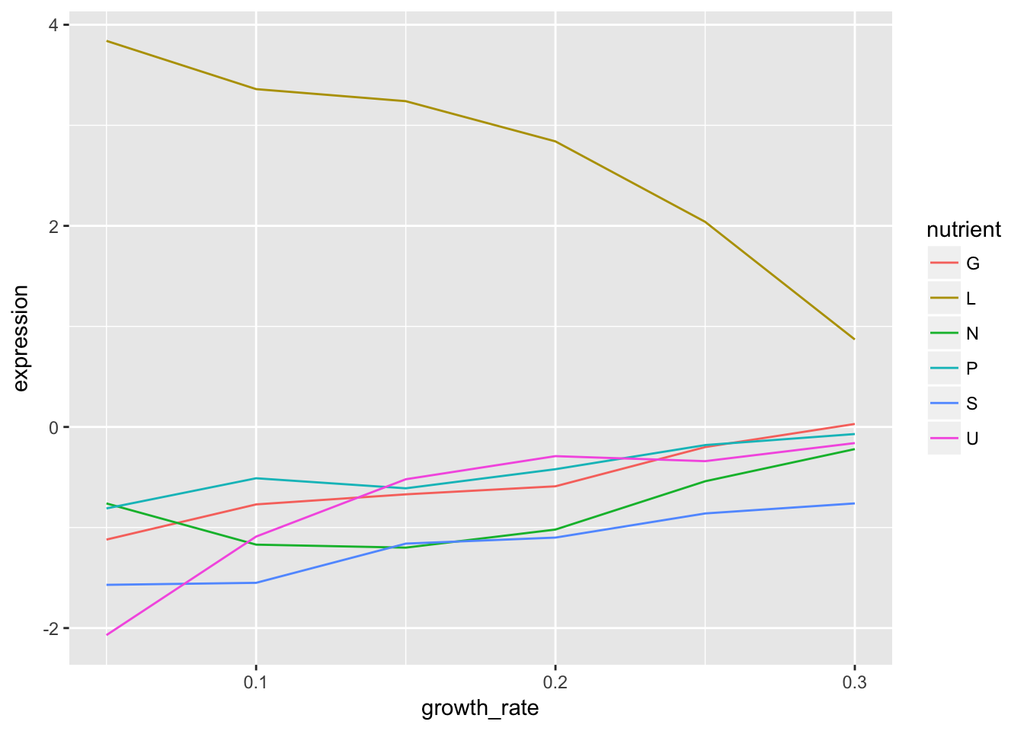

```r
clean %>%
  filter(gene_name == "LEU1") %>%
  ggplot(aes(x = growth_rate, y = expression)) +
    geom_line(aes(colour = nutrient))
```

### What are some conclusions you can make from this data?

- When leucine is limiting the expression of LEU1 is higher than when any of the other nutrients are limiting.
- As growth rate increase the expresison of LEU1 decreases but only in leucine limiting conditions. In all other conditions it increases as growth rate increases.

### What biological process is LEU1 classified as?

leucine biosynthesis

### Filter your cleaned data for all genes that are in the same biological process as LEU1.

```r
clean %>%
  filter(BP == "leucine biosynthesis")
```

```
## # A tibble: 144 x 8
##    gene_name BP                   MP      gene… numb… nutr… growt… expres…
##    <chr>     <chr>                <chr>   <chr> <chr> <chr>  <dbl>   <dbl>
##  1 LEU9      leucine biosynthesis 2-isop… YOR1… " 10… G     0.0500 -0.0800
##  2 LEU1      leucine biosynthesis 3-isop… YGL0… " 10… G     0.0500 -1.12
##  3 LEU2      leucine biosynthesis 3-isop… YCL0… " 10… G     0.0500 -0.590
##  4 LEU4      leucine biosynthesis 2-isop… YNL1… " 10… G     0.0500  2.61
##  5 LEU9      leucine biosynthesis 2-isop… YOR1… " 10… G     0.100  -0.0700
##  6 LEU1      leucine biosynthesis 3-isop… YGL0… " 10… G     0.100  -0.770
##  7 LEU2      leucine biosynthesis 3-isop… YCL0… " 10… G     0.100  -0.710
##  8 LEU4      leucine biosynthesis 2-isop… YNL1… " 10… G     0.100   1.53
##  9 LEU9      leucine biosynthesis 2-isop… YOR1… " 10… G     0.150  -0.660
## 10 LEU1      leucine biosynthesis 3-isop… YGL0… " 10… G     0.150  -0.670
## # ... with 134 more rows
```

### Make a plot of these genes, the same as you had for LEU1 but faceted by gene.

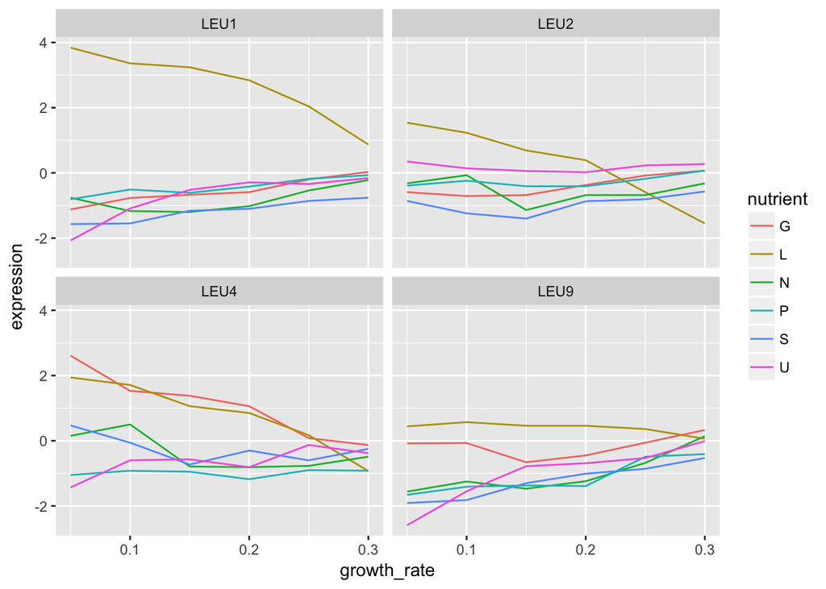

```r
clean %>%
  filter(BP == "leucine biosynthesis") %>%
  ggplot(aes(x = growth_rate, y = expression)) +
    geom_line(aes(colour = nutrient)) +
    facet_wrap(~gene_name)
```

### Do any of the other genes follow the same pattern as LEU1?

LEU2 seems to but the expression difference in leucine limiting conditions is not quite so high.

### Pretty it up

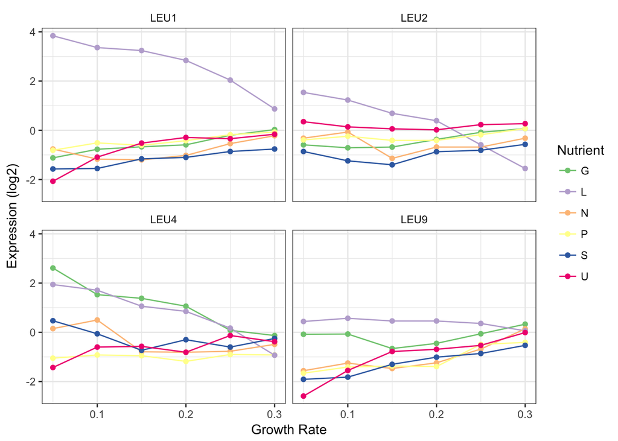

```r
clean %>%
  filter(BP == "leucine biosynthesis") %>%
  ggplot(aes(x = growth_rate, y = expression, colour = nutrient)) +
    geom_line() +
    geom_point() +
    facet_wrap(~gene_name) +
    scale_color_brewer("Nutrient", palette = "Accent") +
    theme_bw() +
    labs(x = "Growth Rate", y = "Expression (log2)") +
    theme(strip.background = element_blank())
```

### Bonus: Changing nutrient names

```r
nutrient_key = c(
  G = "Glucose",
  N = "Ammonium",
  P = "Phosphate",
  S = "Sulfate",
  U = "Uracil",
  L = "Leucine"
)
nutrient_key["P"]
```

```
##           P
## "Phosphate"
```

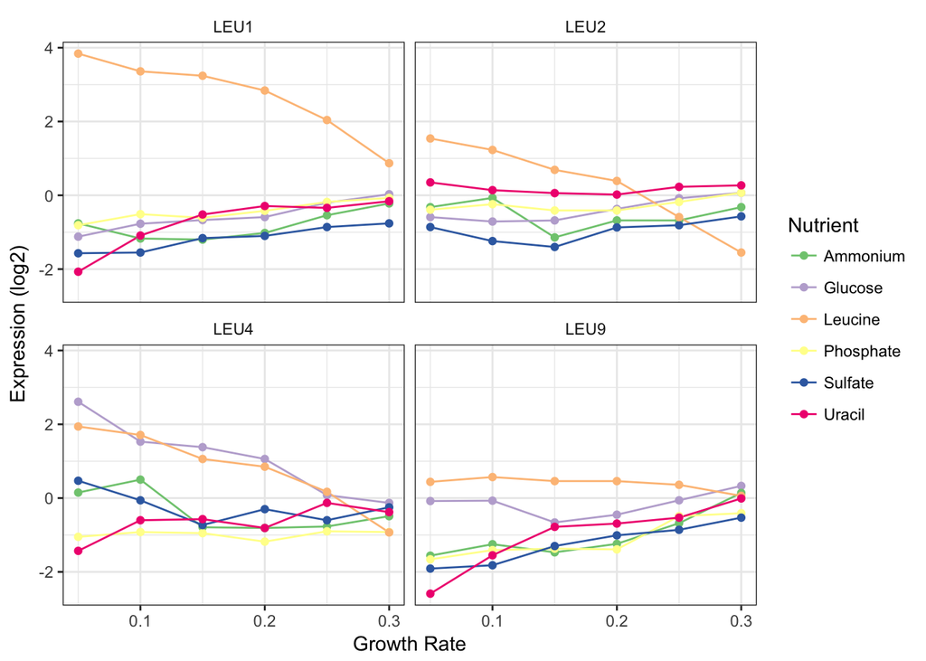

```r
clean %>%
  mutate(nutrient_names = nutrient_key[nutrient]) %>%
    filter(BP == "leucine biosynthesis") %>%
    ggplot(aes(x = growth_rate, y = expression, colour = nutrient_names)) +
    geom_line() +
    geom_point() +
    facet_wrap(~gene_name) +
    scale_color_brewer("Nutrient", palette = "Accent") +
    theme_bw() +
    labs(x = "Growth Rate", y = "Expression (log2)") +
    theme(strip.background = element_blank())
```

## Task 4: Heatmaps

### Start by installing the `pheatmap` package from CRAN. Have a look at the help page for the `pheatamp()` function. Which argument specifies the data? What format does it need?

```r
#install.packages("pheatmap")
library(pheatmap)
?pheatmap
```

Looks like `pheatmap()` needs a numeric matix given with the `mat` arguments, which is the first and only required arugment.

### Using what you learned from the help function get the gene expression data into a format that `pheatmap()` can use. Think about what you want your heatmap to look like - what are the columns and rows?

Here we’re going to go back to our pre-tidied data. This doesn’t negate the work we did to tidy it nor does it mean the the data is now ‘dirty’ or bad somehow. Tidy data is standardized but many R tools still don’t work with data in this format and so we must adapt.

```r
head(raw)
```

```
## # A tibble: 6 x 40
##   GID    YORF  NAME   GWEI…   G0.05    G0.1  G0.15    G0.2   G0.25    G0.3
##   <chr>  <chr> <chr>  <int>   <dbl>   <dbl>  <dbl>   <dbl>   <dbl>   <dbl>
## 1 GENE1… A_06… SFB2 …     1 -0.240  -0.130  -0.210 -0.150  -0.0500 -0.0500
## 2 GENE4… A_06… || bi…     1  0.280   0.130  -0.400 -0.480  -0.110   0.170
## 3 GENE4… A_06… QRI7 …     1 -0.0200 -0.270  -0.270 -0.0200  0.240   0.250
## 4 GENE1… A_06… CFT2 …     1 -0.330  -0.410  -0.240 -0.0300 -0.0300  0
## 5 GENE5… A_06… SSO2 …     1  0.0500  0.0200  0.400  0.340  -0.130  -0.140
## 6 GENE2… A_06… PSP2 …     1 -0.690  -0.0300  0.230  0.200   0      -0.270
## # ... with 30 more variables: N0.05 <dbl>, N0.1 <dbl>, N0.15 <dbl>, N0.2
## #   <dbl>, N0.25 <dbl>, N0.3 <dbl>, P0.05 <dbl>, P0.1 <dbl>, P0.15 <dbl>,
## #   P0.2 <dbl>, P0.25 <dbl>, P0.3 <dbl>, S0.05 <dbl>, S0.1 <dbl>, S0.15
## #   <dbl>, S0.2 <dbl>, S0.25 <dbl>, S0.3 <dbl>, L0.05 <dbl>, L0.1 <dbl>,
## #   L0.15 <dbl>, L0.2 <dbl>, L0.25 <dbl>, L0.3 <dbl>, U0.05 <dbl>, U0.1
## #   <dbl>, U0.15 <dbl>, U0.2 <dbl>, U0.25 <dbl>, U0.3 <dbl>
```

```r
hm_mat = raw %>%
  select(-GID, -YORF, -NAME, -GWEIGHT) %>%
  as.matrix()

class(hm_mat)
```

```
## [1] "matrix"
```

```r
typeof(hm_mat)
```

```
## [1] "double"
```

### Once you’ve got data in the correct format start by making a simple heatmap with default parameters. Do you like it? Is there anything wrong with it? What would change from a data interpretation perspective? What about from aethetics perspective?

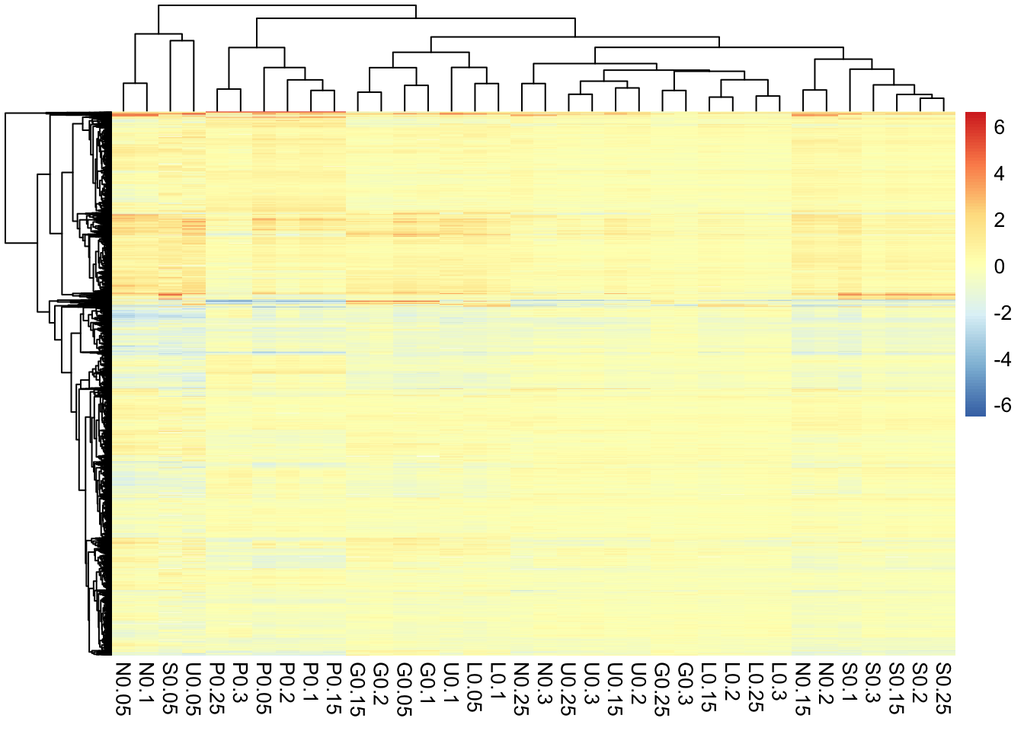

```r
pheatmap(hm_mat)
```

Overall this actually looks pretty good. Because these data have already been normalized and scaled we don’t need to do much here but there are few tweaks that may help. * The default is to order both the rows and columns, however, because this is a timecourse experiment we may not want to order the columns. In fact if we look at the raw data we see that the columns are already ordered by time.  
* The colours are better than the typical red/green (which you should NEVER use, BTW) but still leave something to be desired. This could be changed in a final version of the plot. Note that we have a diverging colour scale with values ranging from -6 to +6. This is becuase these data are mean-centred. Blue (negative) values are below the mean for that gene and red values (positive) are above the mean for that gene. Yellow is the mean expression for that gene. Mean-centering is a handy way to show fold-changes, but should always be displayed with a diverging colour scale.

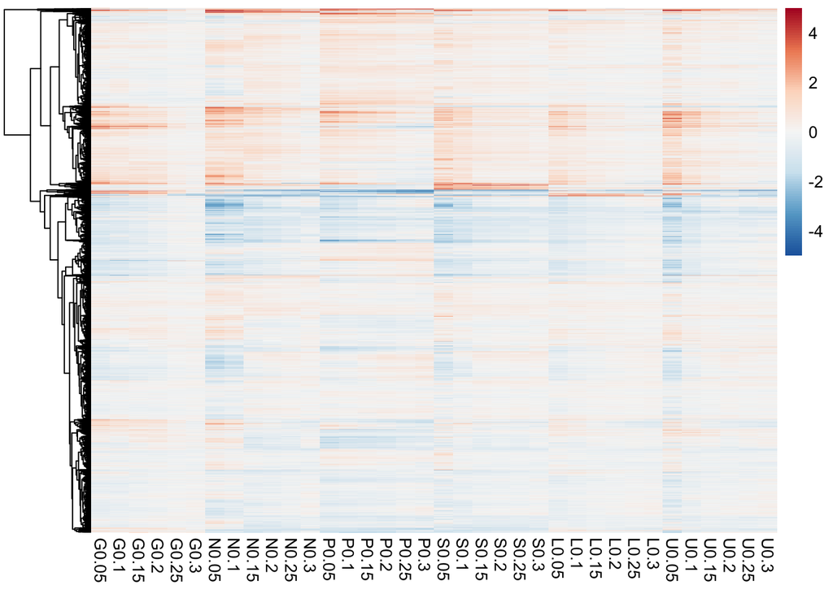

```r
library(RColorBrewer)
pheatmap(hm_mat,
         cluster_cols = FALSE,
         color = colorRampPalette(rev(brewer.pal(n = 7, name = "RdBu")))(100),
         breaks = seq(-5, 5, length.out = 101)
)
```